# Stochastic Gradient Descent

# Stochastic Gradient Descent

Replace full gradients with random sample updates and compare the resulting trajectories. Study step-size schedules and variance reduction to understand why noisy iterations can be effective for large learning problems.

## Run this tour

Run the cells in order with a Python 3 kernel. The first cell locates the companion data and toolbox and installs missing dependencies when needed. All worked examples include their implementation directly in this notebook. Random seeds make comparisons reproducible; you can change them to explore other samples.

```python
# Locate the companion toolbox locally, or fetch it for a standalone/Colab copy.
from pathlib import Path
import importlib.util
import os
import subprocess
import sys

working = Path.cwd()
candidates = [working, working / "python", working.parent / "python"]
python_dir = next((p for p in candidates if (p / "nt_toolbox").is_dir()), None)
if python_dir is None:
    checkout = working / "numerical-tours-support"
    if not checkout.exists():
        subprocess.run(
            [
                "git",
                "clone",
                "--depth",
                "1",
                "--branch",
                "master",
                "https://github.com/gpeyre/numerical-tours.git",
                str(checkout),
            ],
            check=True,
        )
    python_dir = checkout / "python"
os.chdir(python_dir)
if str(python_dir) not in sys.path:
    sys.path.insert(0, str(python_dir))
requirements = python_dir / "requirements.txt"
if any(
    importlib.util.find_spec(name) is None
    for name in [
        "numpy",
        "scipy",
        "matplotlib",
        "skimage",
        "sklearn",
        "pywt",
        "ipywidgets",
        "cvxpy",
        "skfmm",
        "autograd",
        "progressbar",
        "celer",
    ]
):
    subprocess.run(
        [sys.executable, "-m", "pip", "install", "-r", str(requirements)], check=True
    )

import numpy as np
import matplotlib.pyplot as plt

np.random.seed(0)
plt.rcParams.update(
    {
        "figure.figsize": (8, 4),
        "figure.dpi": 100,
        "axes.spines.top": False,
        "axes.spines.right": False,
        "font.size": 11,
        "image.cmap": "gray",
    }
)
%matplotlib inline
```

$\newcommand{\dotp}[2]{\langle #1, #2 \rangle}$ $\newcommand{\enscond}[2]{\lbrace #1, #2 \rbrace}$ $\newcommand{\pd}[2]{ \frac{ \partial #1}{\partial #2} }$ $\newcommand{\umin}[1]{\underset{#1}{\min}\;}$ $\newcommand{\umax}[1]{\underset{#1}{\max}\;}$ $\newcommand{\uargmin}[1]{\underset{#1}{argmin}\;}$ $\newcommand{\norm}[1]{\|#1\|}$ $\newcommand{\abs}[1]{\left|#1\right|}$ $\newcommand{\choice}[1]{ \left\{ \begin{array}{l} #1 \end{array} \right. }$ $\newcommand{\pa}[1]{\left(#1\right)}$ $\newcommand{\diag}[1]{{diag}\left( #1 \right)}$ $\newcommand{\qandq}{\quad\text{and}\quad}$ $\newcommand{\qwhereq}{\quad\text{where}\quad}$ $\newcommand{\qifq}{ \quad \text{if} \quad }$ $\newcommand{\qarrq}{ \quad \Longrightarrow \quad }$ $\newcommand{\ZZ}{\mathbb{Z}}$ $\newcommand{\CC}{\mathbb{C}}$ $\newcommand{\RR}{\mathbb{R}}$ $\newcommand{\EE}{\mathbb{E}}$ $\newcommand{\Zz}{\mathcal{Z}}$ $\newcommand{\Ww}{\mathcal{W}}$ $\newcommand{\Vv}{\mathcal{V}}$ $\newcommand{\Nn}{\mathcal{N}}$ $\newcommand{\NN}{\mathcal{N}}$ $\newcommand{\Hh}{\mathcal{H}}$ $\newcommand{\Bb}{\mathcal{B}}$ $\newcommand{\Ee}{\mathcal{E}}$ $\newcommand{\Cc}{\mathcal{C}}$ $\newcommand{\Gg}{\mathcal{G}}$ $\newcommand{\Ss}{\mathcal{S}}$ $\newcommand{\Pp}{\mathcal{P}}$ $\newcommand{\Ff}{\mathcal{F}}$ $\newcommand{\Xx}{\mathcal{X}}$ $\newcommand{\Mm}{\mathcal{M}}$ $\newcommand{\Ii}{\mathcal{I}}$ $\newcommand{\Dd}{\mathcal{D}}$ $\newcommand{\Ll}{\mathcal{L}}$ $\newcommand{\Tt}{\mathcal{T}}$ $\newcommand{\si}{\sigma}$ $\newcommand{\al}{\alpha}$ $\newcommand{\la}{\lambda}$ $\newcommand{\ga}{\gamma}$ $\newcommand{\Ga}{\Gamma}$ $\newcommand{\La}{\Lambda}$ $\newcommand{\Si}{\Sigma}$ $\newcommand{\be}{\beta}$ $\newcommand{\de}{\delta}$ $\newcommand{\De}{\Delta}$ $\newcommand{\phi}{\varphi}$ $\newcommand{\th}{\theta}$ $\newcommand{\om}{\omega}$ $\newcommand{\Om}{\Omega}$ $\newcommand{\eqdef}{\equiv}$

This tour details Stochastic Gradient Descent, applied to the binary logistic classification problem.

We recommend that after doing this Numerical Tours, you apply it to your own data, for instance using a dataset from [LibSVM](https://www.csie.ntu.edu.tw/~cjlin/libsvmtools/datasets/).

*Disclaimer:* these machine learning tours are intended to be overly-simplistic implementations and applications of baseline machine learning methods. For more advanced uses and implementations, we recommend to use a state-of-the-art library, the most well known being [Scikit-Learn](http://scikit-learn.org/)

```python
%matplotlib inline
import numpy as np
import matplotlib.pyplot as plt
```

Usefull function to convert to a column vector.

```python
#  convert to a column vector
def MakeCol(y):
    return y.reshape(-1, 1)


#  convert to a row vector
def MakeRow(y):
    return y.reshape(1, -1)


# find non zero/true elements
def find(x):
    return np.nonzero(x)[0]
```

## Simple Example

Functions and their derivatives.

```python
def f(x, i):
    if i == 1:
        return 1 / 2 * (x - 1) ** 2
    else:
        return 1 / 2 * (x + 1) ** 2


def df(x, i):
    if i == 1:
        return x - 1
    else:
        return x + 1


def F(x):
    return f(x, 1) + f(x, 2)
```

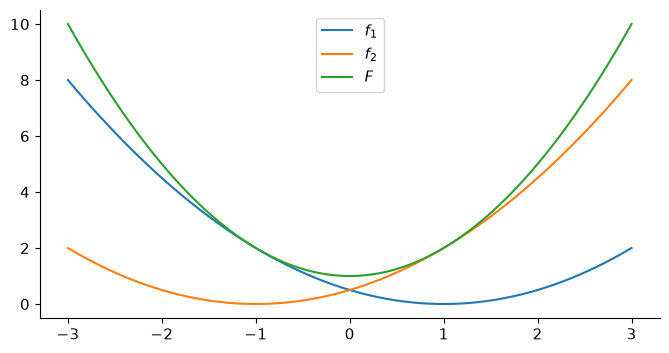

```python
t = np.linspace(-3, 3, 201)
plt.plot(t, f(t, 1))
plt.plot(t, f(t, 2))
plt.plot(t, F(t))
plt.legend(("$f_1$", "$f_2$", "$F$"));
```

Each iteration of SGD reads $$ x_{\ell+1} = x_\ell - \tau_\ell \nabla f_{i(\ell)}(x_\ell) $$ where $ i(\ell) \in \{1,2\} $ is drawn uniformly.

**Worked example 0**

Implement the SGD, with a random initial condition $x_0$. Display several paths (i.e. run several times the algorithm) to vizualize the evolution of the density of the random variable $x_\ell$.

```
(np.float64(-49.95),
 np.float64(1048.95),
 np.float64(-0.5780497052792544),
 np.float64(0.608038211158936))
```

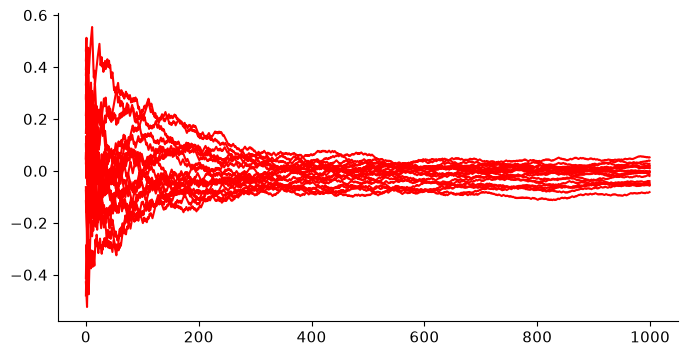

```python
q = 20  # Number of paths computed in parallel.
niter = 1000
x = np.zeros((q, niter))
x[:, 0] = np.random.rand(q, 1).flatten() - 0.5  # Initial conditions.
for i in np.arange(1, niter):
    u = np.random.rand(q, 1) > 0.5
    xx = MakeCol(x[:, i - 1])
    tau = 1.0 / (10 + i)
    x1 = xx - tau * (u * df(xx, 1) + (1 - u) * df(xx, 2))
    x[:, i] = x1.flatten()
# display
plt.clf()
plt.plot(x.transpose(), "r")
plt.axis("tight")
```

## Dataset Loading

We load a subset of the <http://osmot.cs.cornell.edu/kddcup/datasets.html dataset Quantum Physics Dataset> of $n=10000$ features in dimension $78$. The goal in this task is to learn a classification rule that differentiates between two types of particles generated in high energy collider experiments.

Load the dataset. Randomly permute it. Separate the features $X$ from the data $y$ to predict information.

```python
from scipy import io

name = "quantum"
U = io.loadmat("nt_toolbox/data/ml-" + name)
A = U["A"]
A = A[np.random.permutation(A.shape[0]), :]
X = A[:, 0:-1]
y = A[:, -1]
```

Set the classes indexes to be $\{-1,+1\}$.

```python
y = 2 * y - 1
# y must be a column vector
y = MakeCol(y)
```

Remove empty features, normalize $X$.

```python
I = find(np.abs(X).mean(axis=0) > 1e-1)
X = X[:, I]
# normalize
X = X - X.mean(axis=0)
X = X / X.std(axis=0)
```

$n$ is the number of samples, $p$ is the dimensionality of the features,

```python
[n, p] = X.shape
print(n, p)
```

```
10000 46
```

Compute PCA main axes for display.

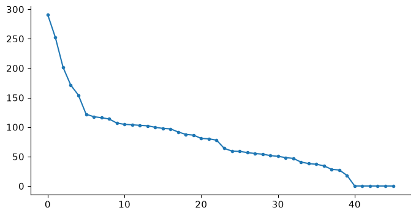

```python
U, s, V = np.linalg.svd(X)
Xr = X.dot(V.transpose())
# display the decay of eigenvalues
plt.plot(s, ".-");
```

Plot the classes.

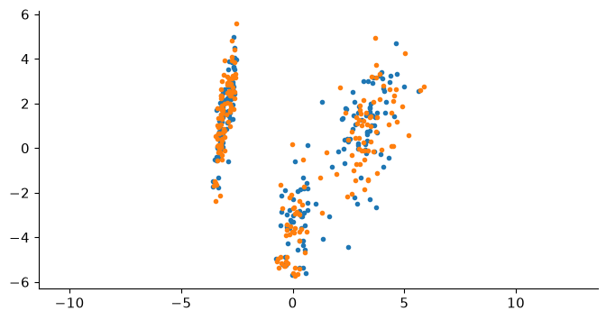

```python
I = find(y == -1)
J = find(y == +1)
plt.plot(Xr[I[0:200], 0], Xr[I[0:200], 1], ".")
plt.plot(Xr[J[0:200], 0], Xr[J[0:200], 1], ".")
plt.axis("equal");
```

[figure not shown]

```python
from mpl_toolkits.mplot3d import Axes3D

fig = plt.figure()
ax = Axes3D(fig)
plt.clf()
ax.scatter(Xr[I[0:200], 0], Xr[I[0:200], 1], Xr[I[0:200], 2], ".")
ax.scatter(Xr[J[0:200], 0], Xr[J[0:200], 1], Xr[J[0:200], 2], ".")
plt.axis("tight");
```

## Batch Gradient Descent (BGD)

We first test the usual (batch) gradient descent (BGD) on the problem of supervised logistic classification.

We refer to the dedicated numerical tour on logistic classification for background and more details about the derivations of the energy and its gradient.

Logistic classification aims at solving the following convex program $$ \umin{w} E(w) \eqdef \frac{1}{n} \sum_{i=1}^n L(\dotp{x_i}{w},y_i) $$ where the logistic loss reads $$ L( s,y ) \eqdef \log( 1+\exp(-sy) ) $$

Define energy $E$ and its gradient $\nabla E$.

```python
def L(s, y):
    return 1 / n * np.sum(np.log(1 + np.exp(-s * y)))


def E(w, X, y):
    return L(X.dot(w), y)


def theta(v):
    return 1 / (1 + np.exp(-v))


def nablaL(s, r):
    return -1 / n * y * theta(-s * y)


def nablaE(w, X, y):
    return X.transpose().dot(nablaL(X.dot(w), y))
```

**Worked example 1**

Implement a gradient descent $$ w_{\ell+1} = w_\ell - \tau_\ell \nabla E(w_\ell). $$ Monitor the energy decay. Test different step size, and compare with the theory (in particular plot in log domain to illustrate the linear rate).

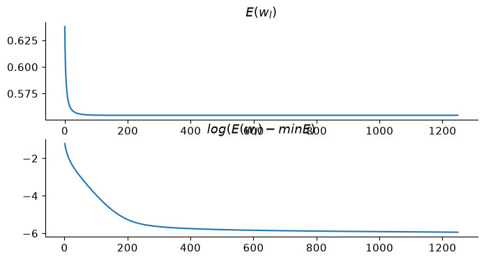

```python
tau = 0.5
niter = 5000
Elist = np.zeros([niter, 1])
w = np.zeros((p, 1))  # initialization
for i in np.arange(0, niter):
    w = w - tau * nablaE(w, X, y)
    Elist[i] = E(w, X, y)
ndisp = int(niter / 4)

## display ##
plt.clf()
plt.subplot(2, 1, 1)
plt.plot(np.arange(0, ndisp), Elist[0:ndisp])
plt.axis("tight")
plt.title("$E(w_l)$")
plt.subplot(2, 1, 2)
plt.plot(np.arange(1, ndisp), np.log10(Elist[1:ndisp] - np.min(Elist)))
plt.axis("tight")
plt.title("$log(E(w_l) - min E)$");
```

## Stochastic Gradient Descent (SGD)

As any empirical risk minimization procedure, the logistic classification minimization problem can be written as $$ \umin{w} E(w) = \frac{1}{n} \sum_i E_i(w) \qwhereq E_i(w) = L(\dotp{x_i}{w},y_i). $$

For very large $n$ (which could in theory even be infinite, in which case the sum needs to be replaced by an expectation or equivalenty an integral), computing $\nabla E$ is prohebitive. It is possible instead to use a stochastic gradient descent (SGD) scheme $$ w_{\ell+1} = w_\ell - \tau_\ell \nabla E_{i(\ell)}(w_\ell) $$ where, for each iteration index $\ell$, $i(\ell)$ is drawn uniformly at random in $ \{1,\ldots,n\} $.

Note that here $$ \nabla E_{i}(w) = x_i \nabla L( \dotp{x_i}{w}, y_i ) \qwhereq \nabla L(u,v) = v \odot \th(-u) $$

```python
def nablaEi(w, i):
    return MakeCol(-y[i] * X[i, :].transpose() * theta(-y[i] * (X[i, :].dot(w))))
```

Note that each step of a batch gradient descent has complexity $O(np)$, while a step of SGD only has complexity $O(p)$. SGD is thus advantageous when $n$ is very large, and one cannot afford to do several passes through the data. In some situation, SGD can provide accurate results even with $\ell \ll n$, exploiting redundancy between the samples.

A crucial question is the choice of step size schedule $\tau_\ell$. It must tends to 0 in order to cancel the noise induced on the gradient by the stochastic sampling. But it should not go too fast to zero in order for the method to keep converging.

A typical schedule that ensures both properties is to have asymptically $\tau_\ell \sim \ell^{-1}$ for $\ell\rightarrow +\infty$. We thus propose to use $$ \tau_\ell \eqdef \frac{\tau_0}{1 + \ell/\ell_0} $$ where $\ell_0$ indicates roughly the number of iterations serving as a "warmup" phase.

One can prove the following convergence result $$ \EE( E(w_\ell) ) - E(w^\star) = O\pa{ \frac{1}{\sqrt{\ell}} }, $$ where $\EE$ indicates an expectation with respect to the i.i.d. sampling performed at each iteration.

Select default values for $ (\ell_0,\tau_0) $.

```python
l0 = 100
tau0 = 0.05
```

**Worked example 2**

Perform the Stochastic gradient descent. Display the evolution of the energy $E(w_\ell)$. One can overlay on top (black dashed curve) the convergence of the batch gradient descent, with a carefull scaling of the number of iteration to account for the fact that the complexity of a batch iteration is $n$ times larger. Perform several runs to illustrate the probabilistic nature of the method. Explore different values for $ (\ell_0,\tau_0) $.

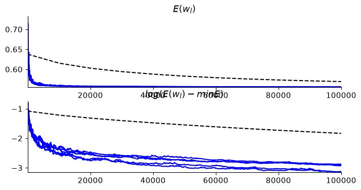

```python
niter = 100000
nsamples = 5
err_rate = 50

ElistS = np.zeros((int(niter / err_rate), nsamples))
for irun in np.arange(0, nsamples):
    w = np.zeros((p, 1))
    for it in np.arange(0, niter):
        if np.mod(it, err_rate) == 1:
            ElistS[int(it / err_rate), irun] = E(w, X, y)
        tau = tau0 / (1 + it / l0)
        i = int(np.floor(np.random.rand() * n))  # draw uniformly
        w = w - tau * nablaEi(w, i)


plt.subplot(2, 1, 1)
plt.plot(np.arange(0, niter, err_rate), ElistS, "b")
plt.plot(1 + np.arange(0, Elist.size) * n, Elist, "k--")
plt.axis((1, niter, ElistS.flatten().min(), ElistS.flatten().max()))
plt.title("$E(w_l)$")

vmin = np.min((np.min(Elist), ElistS.flatten().min()))
u = np.log10(ElistS - vmin + 1e-20)
v = np.log10(Elist - vmin + 1e-20)
plt.subplot(2, 1, 2)
plt.plot(np.arange(0, niter, err_rate), u, "b")
plt.plot(1 + np.arange(0, Elist.size) * n, v, "k--")
plt.axis((1, niter, np.min(u), np.max(u)))
plt.title("$log(E(w_l) - min E)$")
```

## Stochastic Gradient Descent with Averaging (SGA)

Stochastic gradient descent is slow because of the fast decay of $\tau_\ell$ toward zero.

To improve somehow the convergence speed, it is possible to average the past iterate, i.e. run a "classical" SGD on auxiliary variables $ (\tilde w_\ell)_\ell$ $$ \tilde w_{\ell+1} = \tilde w_\ell - \tau_\ell \nabla E_{i(\ell)}(\tilde w_\ell) $$ and output as estimated weight vector the average $$ w_\ell \eqdef \frac{1}{\ell} \sum_{k=1}^\ell \tilde w_\ell. $$ This defines the Stochastic Gradient Descent with Averaging (SGA) algorithm.

Note that it is possible to avoid explicitely storing all the iterates by simply updating a running average as follow $$ w_{\ell+1} = \frac{1}{\ell} \tilde w_\ell + \frac{\ell-1}{\ell} w_\ell. $$

In this case, a typical choice of decay is rather of the form $$ \tau_\ell \eqdef \frac{\tau_0}{1 + \sqrt{\ell/\ell_0}}. $$ Notice that the step size now goes much slower to 0, at rate $\ell^{-1/2}$.

Typically, because the averaging stabilizes the iterates, the choice of $(\ell_0,\tau_0)$ is less important than for SGD.

[Bach proves that](https://arxiv.org/pdf/1303.6149.pdf) for logistic classification, it leads to a faster convergence (the constant involved are smaller) than SGD, since on contrast to SGD, SGA is adaptive to the local strong convexity of $E$.

**Worked example 3**

Implement the Stochastic gradient descent with averaging. Display the evolution of the energy $E(w_\ell)$.

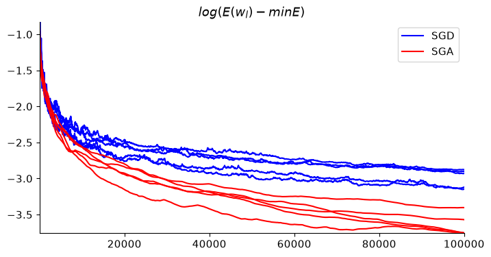

```python
tau0 = 0.05
ell0 = 100

ElistA = np.zeros((int(niter / err_rate), nsamples))
for irun in np.arange(0, nsamples):
    w = np.zeros((p, 1))
    w1 = w
    for it in np.arange(0, niter):
        if np.mod(it, err_rate) == 1:
            ElistA[int(it / err_rate), irun] = E(w, X, y)
        tau = tau0 / (1 + np.sqrt(it / ell0))
        i = int(np.floor(np.random.rand() * n))  # draw uniformly
        w1 = w1 - tau * nablaEi(w1, i)
        w = 1.0 / (it + 1) * w1 + (1 - 1.0 / (it + 1)) * w

# display
vmin = np.min((np.min(Elist), ElistS.flatten().min(), ElistA.flatten().min()))
u = np.log10(ElistS - vmin + 1e-20)
v = np.log10(ElistA - vmin + 1e-20)
plt.clf()
plt.plot(1, np.inf, "b")
plt.plot(1, np.inf, "r")
plt.plot(np.arange(0, niter, err_rate), u, "b")
plt.plot(np.arange(0, niter, err_rate), v, "r")
plt.axis((1, niter, np.min(v), np.max(v)))
plt.title("$log(E(w_l) - min E)$")
plt.legend(("SGD", "SGA"))
```

## Stochastic Averaged Gradient Descent (SAG)

For problem size $n$ where the dataset (of size $n \times p$) can fully fit into memory, it is possible to further improve the SGA method by bookeeping the previous gradient. This gives rise to the [Stochastic Averaged Gradient Descent (SAG)](https://arxiv.org/pdf/1309.2388) algorithm.

We stored all the previously computed gradient in $ (G^i)_{i=1}^n $, which necessitate $n \times p$ memory. The iterates are defined by using a proxy $g$ for the batch gradient, which is progressively enhanced during the iterates.

The algorithm reads $$ h \leftarrow \nabla E_{i(\ell)}(\tilde w_\ell), $$ $$ g \leftarrow g - G^{i(\ell)} + h, $$ $$ G^{i(\ell)} \leftarrow h, $$ $$ w_{\ell+1} = w_\ell - \tau g. $$ Note that in contrast to SGD and SGA, this method uses a fixed step size $\tau$. Similarely to the BGD, in order to ensure convergence, the step size $\tau$ should be of the order of $1/L$ where $L$ is the Lipschitz constant of $E$.

Note that this improvement over SGD and SGA is made possible only because SAG explictely use the fact that $n$ is finite (while SGD and SGA can be extended to infinite $n$ and more general minimization of expectations).

**Worked example 4**

Implement SAG. Display the evolution of the energy $E(w_\ell)$.

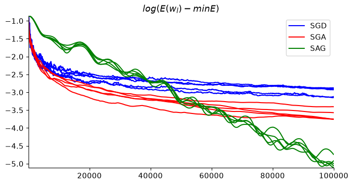

```python
tau = 0.002 / n
ElistG = np.zeros((int(niter / err_rate), nsamples))
for irun in np.arange(0, nsamples):
    w = np.zeros((p, 1))
    G = np.zeros((p, n))  # keep track of gradients
    g = np.zeros((p, 1))
    for it in np.arange(0, niter):
        if np.mod(it, err_rate) == 1:
            ElistG[int(it / err_rate), irun] = E(w, X, y)
        i = int(np.floor(np.random.rand() * n))  # draw uniformly
        g1 = nablaEi(w, i)
        # update grad
        g = g - MakeCol(G[:, i]) + g1
        G[:, i] = g1.flatten()
        #
        w = w - tau * g

vmin = np.min(
    (
        np.min(Elist),
        ElistS.flatten().min(),
        ElistA.flatten().min(),
        ElistG.flatten().min(),
    )
)

u = np.log10(ElistS - vmin + 1e-20)
v = np.log10(ElistA - vmin + 1e-20)
w = np.log10(ElistG - vmin + 1e-20)

plt.clf()
plt.plot(1, np.inf, "b")
plt.plot(1, np.inf, "r")
plt.plot(1, np.inf, "g")
plt.plot(np.arange(0, niter, err_rate), u, "b")
plt.plot(np.arange(0, niter, err_rate), v, "r")
plt.plot(np.arange(0, niter, err_rate), w, "g")
plt.axis((1, niter, np.min(w), np.max(w)))
plt.title("$log(E(w_l) - min E)$")
plt.legend(("SGD", "SGA", "SAG"))
```

## References and further reading

- Léon Bottou, Frank E. Curtis, and Jorge Nocedal. [Optimization Methods for Large-Scale Machine Learning](https://arxiv.org/abs/1606.04838). 2018, SIAM Review 60(2), 223–311. Stochastic gradients, variance reduction, and practical convergence.
- Diederik P. Kingma and Jimmy Ba. [Adam: A Method for Stochastic Optimization](https://arxiv.org/abs/1412.6980). 2015, ICLR. Adaptive stochastic gradient updates for neural network training.
- Trevor Hastie, Robert Tibshirani, and Jerome Friedman. [The Elements of Statistical Learning](https://hastie.su.domains/ElemStatLearn/). 2009, 2nd ed., Springer. Regression, classification, regularization, and model assessment.
- Stephen Boyd and Lieven Vandenberghe. [Convex Optimization](https://web.stanford.edu/~boyd/cvxbook/). 2004, Cambridge University Press. Convexity, duality, optimality conditions, and interior-point methods.
- Ian Goodfellow, Yoshua Bengio, and Aaron Courville. [Deep Learning](https://www.deeplearningbook.org/). 2016, MIT Press. Neural networks, automatic differentiation, and optimization.